# STAT 240 Discussion 8

## Group 4 DIS 314

## Members Present

- Wai Zin Linn, Will Hu
- **ZHAN YU**

## Members Absent

- Martin Lozano

## Questions

### 1

1. A fair coin is tossed repeatedly until the tenth head is tossed. $X_1$ is the number of tails tossed prior to the tenth head.

-This does not fit in binomial model, because the number of trials isn’t decided before the experiment.

2. Four buckets each contain a total of five tokens each, some red and some blue. The number of red tokens in the buckets are 1, 2, 3, and 4 with blue tokens making up the remainder. One token is drawn at random from each bucket. $X_2$ is the total number of red tokens drawn.

-This does not fit in binomial model, because the trials don’t have the same probability of success.

3. A random sample of students in a fitness study. $X_3$ is the mean systolic blood pressure of the sample.

-This does not fit in binomial model, because the blood pressure is a continuous variable, and the result is not binomial.

### 2

Create a data frame with columns `n`, `p`, `x`, `mu`, and `prob` where:

- `n` varies from 2 to 100 by twos (so each `n` value is even: 2, 4, 6, 8, …, 100);
- `p` equals 0.5;
- `x` is `n`/2;
- `mu` is the mean of the Binomial distribution with parameters `n` and `p`;
- `prob` is $P(X = x)$, where X~Binomial(`n`, `p`)

Show the first few rows using `head()`, then respond to the question below.

```r
q2 <- tibble(
  n = seq(2, 100, 2),
  p = 0.5,
  x = n / 2,
  mu = n * p,
  prob = dbinom(x, n, p)
)

head(q2)
```

```
## # A tibble: 6 x 5
##       n     p     x    mu  prob
##   <dbl> <dbl> <dbl> <dbl> <dbl>
## 1     2   0.5     1     1 0.500
## 2     4   0.5     2     2 0.375
## 3     6   0.5     3     3 0.312
## 4     8   0.5     4     4 0.273
## 5    10   0.5     5     5 0.246
## 6    12   0.5     6     6 0.226
```

What is the relationship between `x` and `mu`?

-They are the same

### 3

The central limit theorem implies that the binomial distribution converges to a normal distribution as $n$ increases. This problem will examine one aspect of the convergence, namely the right tail probability of being more than two standard deviations above the mean, $P(X > \mu + 2\sigma)$.

**(a)** What is the probability that a normal random variable with mean $\mu$ and standard deviation $\sigma$ exceeds $\mu + 2 \sigma$? Display answer rounded to four decimal places.

```r
round(1 - pnorm(2, 0, 1), 4)
```

```
## [1] 0.0228
```

Response: 0.0228 **(b)**

Create a data frame with columns `n`, `p`, `mu`, `sigma`, `x`, and `prob` where:  
- `n` varies from 1 to 1000 by ones (1, 2, 3, …, 1000);  
- `p` equals 0.5;  
- `mu` is the mean of the Binomial distribution with parameters `n` and `p`; - `sigma` is the standard deviation of the Binomial distribution with parameters `n` and `p`; - `x` equals `mu` + 2*`sigma`;  
- `prob` is $P(X > x)$, where X~Binomial(`n`, `p`)

Display the first few rows of the data frame with `head()`.

```r
q3_0.5 <- tibble(
  n = seq(1, 1000, 1),
  p = 0.5,
  mu = n * p,
  sigma = sqrt(n * p * (1-p)),
  x = mu + 2*sigma,
  prob = 1 - pbinom(x, n, p)
)
head(q3_0.5)
```

```
## # A tibble: 6 x 6
##       n     p    mu sigma     x   prob
##   <dbl> <dbl> <dbl> <dbl> <dbl>  <dbl>
## 1     1   0.5   0.5 0.5    1.5  0
## 2     2   0.5   1   0.707  2.41 0
## 3     3   0.5   1.5 0.866  3.23 0
## 4     4   0.5   2   1      4    0
## 5     5   0.5   2.5 1.12   4.74 0.0312
## 6     6   0.5   3   1.22   5.45 0.0156
```

**(c)** Plot the right tail probabilities versus $n$, and carryout the following modifications:

- Add a red, dashed, horizontal line at the value you found in part **(a)**.
- Add a smooth curve which lessens the visual impact of the oscillations due to the discreteness of the binomial distribution.

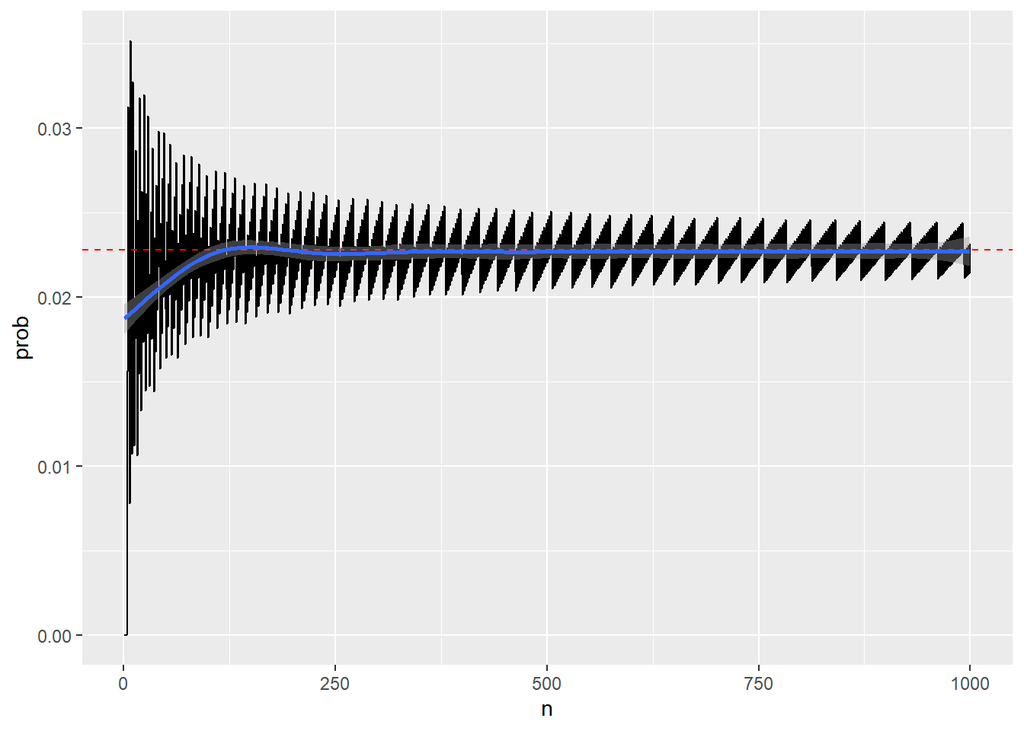

```r
ggplot(q3_0.5, mapping = aes(x = n, y = prob)) +
  geom_line() +
  geom_hline(aes(yintercept = round(1 - pnorm(2, 0, 1), 4)), linetype="dashed", color = "red") +
  geom_smooth()
```

**(d)** Repeat parts **(b)** and **(c)** if $p = 0.005$.

```r
q3_0.005 <- tibble(
  n = seq(1, 1000, 1),
  p = 0.005,
  mu = n * p,
  sigma = sqrt(n * p * (1-p)),
  x = mu + 2*sigma,
  prob = 1 - pbinom(x, n, p)
)
head(q3_0.005)
```

```
## # A tibble: 6 x 6
##       n     p    mu  sigma     x    prob
##   <dbl> <dbl> <dbl>  <dbl> <dbl>   <dbl>
## 1     1 0.005 0.005 0.0705 0.146 0.005
## 2     2 0.005 0.01  0.0997 0.209 0.00998
## 3     3 0.005 0.015 0.122  0.259 0.0149
## 4     4 0.005 0.02  0.141  0.302 0.0199
## 5     5 0.005 0.025 0.158  0.340 0.0248
## 6     6 0.005 0.03  0.173  0.376 0.0296
```

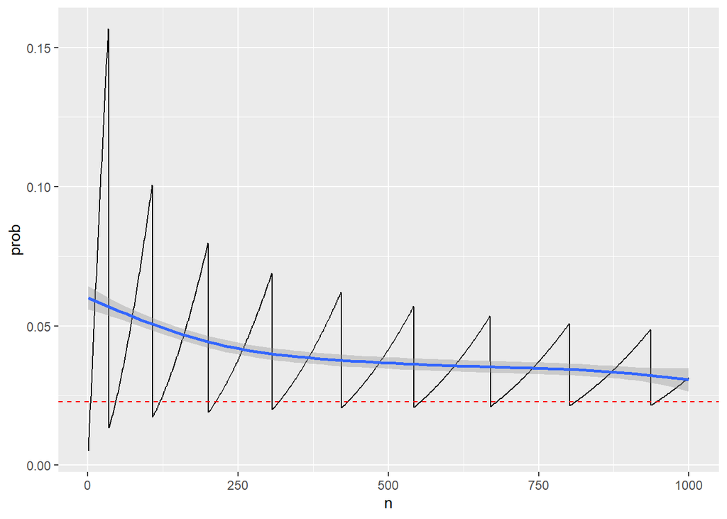

```r
ggplot(q3_0.005, mapping = aes(x = n, y = prob)) +
  geom_line() +
  geom_hline(aes(yintercept = round(1 - pnorm(2, 0, 1), 4)), linetype="dashed", color = "red") +
  geom_smooth()
```

**(e)**

Ignoring the oscillations, how do the patterns of the two smooth curves in the graphs differ from one another, especially when $n$ is large?

### 4

Draw a graph of the binomial distribution with $(n=500, p = 0.5)$ and a graph for the binomial distribution with $(n=500, p = 0.005)$; you may use the `gbinom` function in the *ggprob.R* script. Scale these graphics so that the x axis is restricted to where the probabilities are relatively large; set `scale=TRUE` in the `gbinom` function to accomplish this.

Overlay each plot with a red normal density with a mean and standard deviation that matches the mean and standard deviation of the corresponding binomial distribution. Consider the `geom_norm_density` function in the *ggprob.R* script.

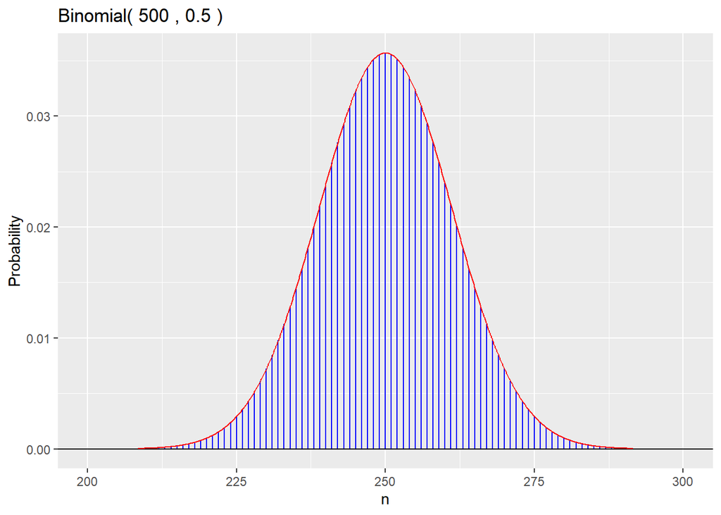

```r
gbinom(500, 0.5, a = 200, b = 300) +
  geom_norm_density(500*0.5, sqrt(500 * 0.5 * (1-0.5)), scale = TRUE, color = "red") +
  xlab("n")
```

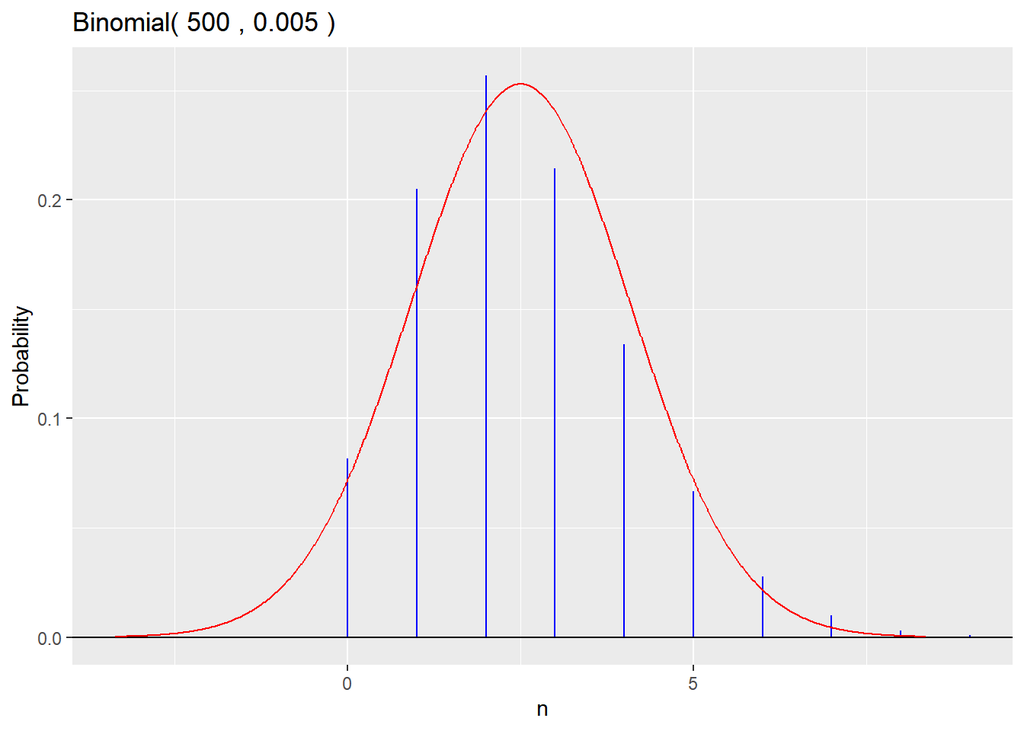

```r
gbinom(500, 0.005, a = -5, b = 9) +
  geom_norm_density(500*0.005, sqrt(500 * 0.005 * (1-0.005)), scale = TRUE, color = "red") +
  xlab("n")
```